# WriteUp

Patrick Schornboeck

10/30/2017

# Background and Intention

Using devices such as Jawbone Up, Nike FuelBand, and Fitbit it is now possible to collect a large amount of data about personal activity relatively inexpensively. One thing that people regularly do is quantify how much of a particular activity they do, but they rarely quantify how well they do it. In this project, your goal will be to use data from accelerometers on the belt, forearm, arm, and dumbell of 6 participants. They were asked to perform barbell lifts correctly and incorrectly in 5 different ways. More information is available from the website here: http://groupware.les.inf.puc-rio.br/har (see the section on the Weight Lifting Exercise Dataset).

In here, it is described how I conducted the data cleaning, analysis as well as how I built and evaluated the prediction model.

# Seting up the analysis and machine learning

# Cleaning the data

After reading in the complete data, it shall be cleaned, pusuing the following goal:

**reducing the complexity (i.e. number of columns) for the model building**

This is performed by removing:

- columns that include mostly NAs
- columns that include data in no correlation with the movement (e.g. time stamps and user names)
- columns that are highly correlated with another one

The precise code can be looked up in the R-script.

The following plot illustrates the correlation between the remaining variables.

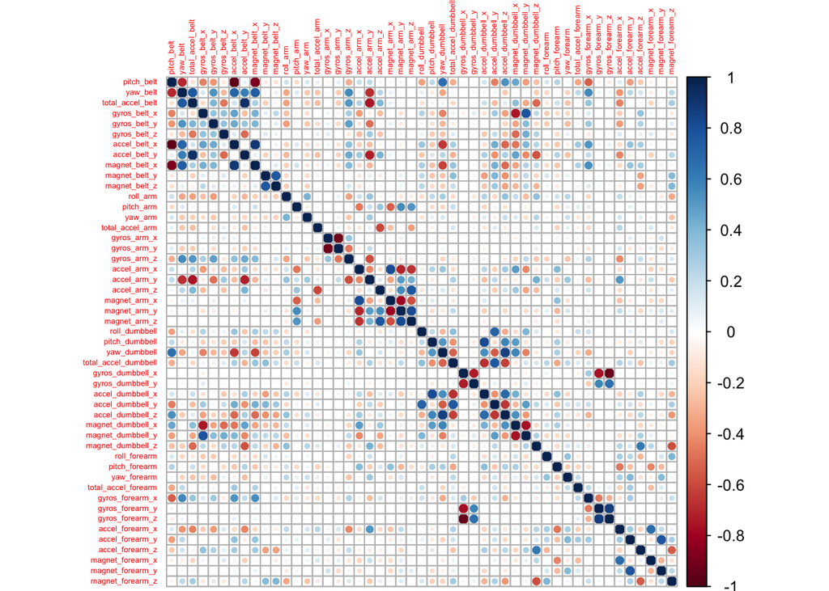

**In total, we reduced the number of variables from 160 to 50, using X = 0.8 for the proportion of NAs in a column and Y = 0.98 for the covariance.**

# Coming up with the right Model

## Building the Model with the myTrain dataset

From what I experienced in class, I thought that the random forest algorithm might get the highest accuracy for this kind of problem. This hypothesis shall be checked by applying its prediction first to the myTrain dataset. According to the outcome, we can decide afterwards on applying a different model or using a combination of various models.

```r
ModRF <- randomForest(classe~., data = myTrain, ntree = 200)
```

When I first tried to build a random forest model with caret (method “rf”) and default settings, it did not get a result for a couple of hours. After that, I decided on further reducing the number of variables and restricting the number of trees to 200 (ntree = 200) while the default is 500. This model was then built in the matter of a few moments.

## Evaluating the random forest model on the training set: myTrain

```r
TrainPred <- predict(ModRF, myTrain)
confMatTrain <- confusionMatrix(TrainPred, myTrain$classe)
confMatTrain
```

```
## Confusion Matrix and Statistics
##
##           Reference
## Prediction    A    B    C    D    E
##          A 3906    0    0    0    0
##          B    0 2658    0    0    0
##          C    0    0 2396    0    0
##          D    0    0    0 2252    0
##          E    0    0    0    0 2525
##
## Overall Statistics
##
##                Accuracy : 1
##                  95% CI : (0.9997, 1)
##     No Information Rate : 0.2843
##     P-Value [Acc > NIR] : < 2.2e-16
##
##                   Kappa : 1
##  Mcnemar's Test P-Value : NA
##
## Statistics by Class:
##
##                      Class: A Class: B Class: C Class: D Class: E
## Sensitivity            1.0000   1.0000   1.0000   1.0000   1.0000
## Specificity            1.0000   1.0000   1.0000   1.0000   1.0000
## Pos Pred Value         1.0000   1.0000   1.0000   1.0000   1.0000
## Neg Pred Value         1.0000   1.0000   1.0000   1.0000   1.0000
## Prevalence             0.2843   0.1935   0.1744   0.1639   0.1838
## Detection Rate         0.2843   0.1935   0.1744   0.1639   0.1838
## Detection Prevalence   0.2843   0.1935   0.1744   0.1639   0.1838
## Balanced Accuracy      1.0000   1.0000   1.0000   1.0000   1.0000
```

**The perfect training set accuracy gives us confidence to further apply the random forest model.**

## Evaluating the random forest model on the testing set: myTest

```r
TestPred <- predict(ModRF, myTest)
confMatTest <- confusionMatrix(TestPred, myTest$classe)
confMatTest
```

```
## Confusion Matrix and Statistics
##
##           Reference
## Prediction    A    B    C    D    E
##          A 1672    8    0    0    0
##          B    2 1129   10    0    0
##          C    0    2 1015   10    1
##          D    0    0    1  953    3
##          E    0    0    0    1 1078
##
## Overall Statistics
##
##                Accuracy : 0.9935
##                  95% CI : (0.9911, 0.9954)
##     No Information Rate : 0.2845
##     P-Value [Acc > NIR] : < 2.2e-16
##
##                   Kappa : 0.9918
##  Mcnemar's Test P-Value : NA
##
## Statistics by Class:
##
##                      Class: A Class: B Class: C Class: D Class: E
## Sensitivity            0.9988   0.9912   0.9893   0.9886   0.9963
## Specificity            0.9981   0.9975   0.9973   0.9992   0.9998
## Pos Pred Value         0.9952   0.9895   0.9874   0.9958   0.9991
## Neg Pred Value         0.9995   0.9979   0.9977   0.9978   0.9992
## Prevalence             0.2845   0.1935   0.1743   0.1638   0.1839
## Detection Rate         0.2841   0.1918   0.1725   0.1619   0.1832
## Detection Prevalence   0.2855   0.1939   0.1747   0.1626   0.1833
## Balanced Accuracy      0.9985   0.9943   0.9933   0.9939   0.9980
```

**We achieve an overall testing accuracy of 99.3542906 %**

```r
OSE <- 1- sum(TestPred == myTest$classe)/length(TestPred)
```

**The out of sample error is 0.6457094 %**

## Applying the random forest model on the test set for the quiz: testing

```r
QuizPred <- predict(ModRF, testing)
QuizPred
```

```
##  1  2  3  4  5  6  7  8  9 10 11 12 13 14 15 16 17 18 19 20
##  B  A  B  A  A  E  D  B  A  A  B  C  B  A  E  E  A  B  B  B
## Levels: A B C D E
```

**With that model, I achieved 20 out of 20 points at the quiz which further increases confidence in the chosen model**